Skip to main content

# Predicting Student Depression Using Demographic, Academic, and Well-Being Factors

Authors

Isaac Wu

Quinn Scheider

Ankit Chhikara

Shrey Mudgal

# 1 Summary

To summarize, this study analyzes the Student Depression Dataset - comprising 4,464 student records across 12 demographic, socioeconomic, academic, and personal well-being features - to identify key risk factors and predict depression status. Following data cleaning and an 80/20 train-test split to prevent data leakage, exploratory data analysis revealed an imbalanced target distribution alongside noticeable distributional shifts across academic and personal indicators such as CGPA and health status. Using a leak-free preprocessing pipeline evaluated via 5-fold stratified cross-validation, a logistic regression classifier achieved 97.1% accuracy (0.961 precision, 0.929 recall, and a 0.945 F1-score) on the held-out test set, substantially outperforming the 73.1% majority-class baseline. Model coefficients identified personal health condition as the strongest predictor—with critical health elevating depression risk and good health reducing it—followed by relationship status, marital status, family background, and social circle, highlighting the importance of prioritizing recall in future iterations to ensure at-risk students are reliably identified.

# 2 Introduction

Student mental health is a critical factor influencing academic performance, retention, and overall well-being in higher education. Understanding which demographic, academic, social, and lifestyle variables correlate with student depression enables universities to identify at-risk individuals early and allocate targeted support resources effectively.

In this analysis, we examine the **Student Depression Dataset** (`4,464` student records across `12` features), which captures demographic attributes (`Gender`, `Age`, `Home_division`), socioeconomic and living conditions (`Family_background`, `Living_style`, `Cost_without_study`), academic standing (`Current_semester`, `CGPA`), and personal well-being indicators (`Relationship_status`, `Marital_status`, `friend_circle`, `Health_condition`). Such survey-based samples are commonly used to estimate the prevalence and correlates of student mental health (Auerbach et al., 2018). Specifically, this study addresses the following research question: To what extent can demographic, socioeconomic, academic, and self-reported well-being features accurately predict a student’s recorded depression label (Depression: Yes vs. No) in this survey dataset? Note that this predictive task aims solely to classify the binary outcome label recorded in the dataset for early risk screening, rather than providing a clinical or medical diagnosis of depression.

Data source: Student Depression Detection Dataset, by mkhoirulmustaqim (n.d.), available on [Kaggle](https://www.kaggle.com/datasets/mkhoirulmustaqim/student-depression-detection-dataset).

# 3 Methodology

## 3.1 Overview of Analytical Workflow

1. **Data Acquisition (`data/raw/`):** Download the raw CSV dataset from its source URL and save an unmodified copy to `../data/raw/Student_Depression_Dataset.csv`.
2. **Data Wrangling & Cleaning (`data/processed/`):** Standardize column names, verify data types, check for missing values or duplicate rows, encode the binary target variable (`Depression`: `Yes` $\rightarrow 1$, `No` $\rightarrow 0$), and export the cleaned dataset to `../data/processed/student_depression_clean.csv`.
3. **Train-Test Split (The Golden Rule):** Partition the dataset into an **80% training set** ($n = 3,571$) and a **20% held-out test set** ($n = 893$) prior to conducting any exploratory data analysis, summary statistics, or feature transformations. The test set remains strictly untouched until final model evaluation.
4. **Exploratory Data Analysis (Training Set Only):** Compute summary statistics and generate Altair visualizations on `train_df` to inspect class balance, numerical feature skewness, and depression rates across categorical subgroups.
5. **Model Training, Cross-Validation, and Evaluation:** Build a `scikit-learn` `ColumnTransformer` preprocessing pipeline inside `Pipeline` objects to avoid validation leakage, compare a logistic regression classifier against a majority-class baseline via 5-fold stratified cross-validation, and evaluate the top-performing model on the held-out test set. All modeling is implemented with the `scikit-learn` library (Pedregosa et al., 2011).

## 3.2 Model Selection and Evaluation Metrics

- **Dummy Classifier (`most_frequent`):** Serves as a naive baseline predicting the majority class (`No`) for every student.
- **Logistic Regression (Standard):** Models the log-odds of depression as a linear combination of standardized numerical features and encoded categorical indicators, offering direct interpretability via odds ratios.

# 4 Data Loading, Initial Inspection and Preprocessing

In this section, we load the student depression dataset and inspect the first few rows to understand the structure of the features and target variable (`Depression`).

```python
import pandas as pd
import numpy as np
import matplotlib.pyplot as plt
import kagglehub
import os
import glob
import shutil


#Data Loading
os.makedirs("../data/raw", exist_ok=True)
raw_path = "../data/raw/Student_Depression_Dataset.csv"

if not os.path.exists(raw_path):
  # Downloads the latest version of the dataset to local cache
  download_dir = kagglehub.dataset_download(
      "mkhoirulmustaqim/student-depression-detection-dataset"
  )

  # Find the CSV file in the downloaded folder and copy it to data/raw/
  csv_files = glob.glob(os.path.join(download_dir, "*.csv"))
  shutil.copy(csv_files[0], raw_path)


df = pd.read_csv(raw_path)

print(df.head())
```

```
   Gender  Age Family_background Relationship_status Marital_status  \
0  Female   22      Middle class              Single      Unmarried
1    Male   19      Middle class              Single      Unmarried
2    Male   23      Middle class              Single      Unmarried
3    Male   20      Middle class         Complicated      Unmarried
4  Female   21      Middle class              Single      Unmarried

  Living_style  Current_semester  CGPA friend_circle Health_condition  \
0     Bachelor                 8  3.43           Yes         Critical
1     Bachelor                 2  3.70           Yes         Abnormal
2       Family                 8  3.28            No         Abnormal
3       Family                 2  3.77            No             Good
4       Family                 1  4.00            No         Abnormal

   Cost_without_study Home_division Depression
0               10113    Chittagong        Yes
1               13815    Chittagong        Yes
2               15450         Dhaka        Yes
3               17413         Dhaka         No
4               16693         Dhaka        Yes
```

```python
# Clean any leading/trailing whitespace in column names
df.columns = df.columns.str.strip()

print(f"Dataset Shape: {df.shape[0]} rows, {df.shape[1]} columns\n")
print("--- Data Types & Non-Null Counts ---")
df.info()

print("\n--- Missing Values ---")
missing = df.isnull().sum()
print(missing[missing > 0] if missing.sum() > 0 else "No missing values detected.")

print(f"\nDuplicate Rows: {df.duplicated().sum()}")
```

```
Dataset Shape: 4464 rows, 13 columns

--- Data Types & Non-Null Counts ---
<class 'pandas.DataFrame'>
RangeIndex: 4464 entries, 0 to 4463
Data columns (total 13 columns):
 #   Column               Non-Null Count  Dtype
---  ------               --------------  -----
 0   Gender               4464 non-null   str
 1   Age                  4464 non-null   int64
 2   Family_background    4464 non-null   str
 3   Relationship_status  4464 non-null   str
 4   Marital_status       4464 non-null   str
 5   Living_style         4464 non-null   str
 6   Current_semester     4464 non-null   int64
 7   CGPA                 4464 non-null   float64
 8   friend_circle        4464 non-null   str
 9   Health_condition     4464 non-null   str
 10  Cost_without_study   4464 non-null   int64
 11  Home_division        4464 non-null   str
 12  Depression           4464 non-null   str
dtypes: float64(1), int64(3), str(9)
memory usage: 453.5 KB

--- Missing Values ---
No missing values detected.

Duplicate Rows: 0
```

*So the data looks complete without any missing values and duplicated rows.* Next, we examine the distributions of our binary target variable, Depression, to check for class imbalance. Before that we shall transform the target column from string to boolean (0 and 1) and split the dataset into training and testing set.

```python
df['Depression'] = df['Depression'].str.strip().map({'Yes': 1, 'No': 0})
df.head()
```

|  | Gender | Age | Family_background | Relationship_status | Marital_status | Living_style | Current_semester | CGPA | friend_circle | Health_condition | Cost_without_study | Home_division | Depression |
| --- | --- | --- | --- | --- | --- | --- | --- | --- | --- | --- | --- | --- | --- |
| 0 | Female | 22 | Middle class | Single | Unmarried | Bachelor | 8 | 3.43 | Yes | Critical | 10113 | Chittagong | 1 |
| 1 | Male | 19 | Middle class | Single | Unmarried | Bachelor | 2 | 3.70 | Yes | Abnormal | 13815 | Chittagong | 1 |
| 2 | Male | 23 | Middle class | Single | Unmarried | Family | 8 | 3.28 | No | Abnormal | 15450 | Dhaka | 1 |
| 3 | Male | 20 | Middle class | Complicated | Unmarried | Family | 2 | 3.77 | No | Good | 17413 | Dhaka | 0 |
| 4 | Female | 21 | Middle class | Single | Unmarried | Family | 1 | 4.00 | No | Abnormal | 16693 | Dhaka | 1 |

Now save it as processed data in the processed folder.

```python
df.to_csv('../data/processed/student_depression_clean.csv', index=False)
```

Check if we revise the target correctly. Therefore, the dataset will split into training and testing set using sklearn package.

```python
from sklearn.model_selection import train_test_split

# 1. Split DataFrame into 80% train and 20% test (before any EDA or preprocessing)
train_df, test_df = train_test_split(
    df,
    test_size=0.20,
    random_state=42,
    stratify=df['Depression']
)

# 2. Separate features (X) and target (y) for modeling
X_train = train_df.drop(columns=['Depression'])
y_train = train_df['Depression']

X_test = test_df.drop(columns=['Depression'])
y_test = test_df['Depression']
```

# 5 Exploratory Data Analysis (EDA)

Following the train-test split, we conduct exploratory data analysis exclusively on the training set (train_df, $n = 3,571$) to prevent data leakage. Specifically, we examine the class balance of the target variable (Depression) alongside the summary statistics and distributions of numerical and categorical features to identify key risk patterns and inform our preprocessing pipeline.

```python
import altair as alt

# Allow Altair to render datasets with >5,000 rows
alt.data_transformers.disable_max_rows()
alt.renderers.enable('html')

target_col = 'Depression'

bars = alt.Chart(train_df).mark_bar().encode(
    x=alt.X(f'{target_col}:N', title='Depression Status', axis=alt.Axis(labelAngle=0)),
    y=alt.Y('count():Q', title='Count'),
    color=alt.Color(f'{target_col}:N', legend=None, scale=alt.Scale(scheme='pastel1')),
    tooltip=[alt.Tooltip(f'{target_col}:N', title='Depression'), alt.Tooltip('count():Q', title='Count')]
).properties(
    width=300,
    height=250,
    title=f'Target Variable Distribution ({target_col})'
)

text = bars.mark_text(
    align='center',
    baseline='bottom',
    dy=-4
).encode(
    text='count():Q'
)

(bars + text)
```

[interactive chart not shown]

Figure 1: Distribution of target variable (Depression)

Figure 1 shows the class distribution of the target variable. The dataset is not balanced: the proportion of students with depression is about one-third of the proportion without depression. A class-weighted model may help address this imbalance. Next, we examine the distributions of numeric data and categorical features. Table 1 summarizes the numerical features, and Table 2 summarizes the categorical features.

```python
# Summary statistics for numerical features
train_df.describe()
```

Table 1: Description of numerical features

|  | Age | Current_semester | CGPA | Cost_without_study | Depression |
| --- | --- | --- | --- | --- | --- |
| count | 3571.000000 | 3571.000000 | 3571.000000 | 3571.000000 | 3571.000000 |
| mean | 22.620274 | 5.416410 | 3.411585 | 11181.042285 | 0.269112 |
| std | 2.020559 | 2.591832 | 0.388598 | 6613.300623 | 0.443561 |
| min | 17.000000 | 0.000000 | 2.250000 | 0.000000 | 0.000000 |
| 25% | 21.000000 | 3.000000 | 3.150000 | 6100.000000 | 0.000000 |
| 50% | 23.000000 | 5.000000 | 3.490000 | 9400.000000 | 0.000000 |
| 75% | 24.000000 | 7.000000 | 3.710000 | 15232.500000 | 1.000000 |
| max | 28.000000 | 12.000000 | 4.000000 | 32000.000000 | 1.000000 |

```python
train_df.describe(include=['object', 'category'])
```

Table 2: Description of categorical features

|  | Gender | Family_background | Relationship_status | Marital_status | Living_style | friend_circle | Health_condition | Home_division |
| --- | --- | --- | --- | --- | --- | --- | --- | --- |
| count | 3571 | 3571 | 3571 | 3571 | 3571 | 3571 | 3571 | 3571 |
| unique | 2 | 3 | 3 | 3 | 2 | 2 | 4 | 8 |
| top | Female | Middle class | Single | Unmarried | Bachelor | Yes | Normal | Dhaka |
| freq | 1972 | 2136 | 2232 | 2882 | 1952 | 2577 | 1424 | 1241 |

## 5.1 Data Distribution of Numeric Variables Grouped by Depression Status

```python
num_cols = [c for c in train_df.select_dtypes(include=[np.number]).columns if c != target_col]

print(num_cols)


if num_cols:
    rows = []
    for col in num_cols:
        dens = alt.Chart(train_df).transform_density(
            col,
            as_=[col, 'density'],
            groupby=[target_col]
        ).mark_area(opacity=0.45).encode(
            x=alt.X(f'{col}:Q', title=col),
            y=alt.Y('density:Q', title='Density', stack=None),
            color=alt.Color(f'{target_col}:N', scale=alt.Scale(scheme='set2')),
            tooltip=[
                alt.Tooltip(f'{col}:Q', format='.2f'),
                alt.Tooltip('density:Q', format='.4f'),
                alt.Tooltip(f'{target_col}:N', title='Depression')
            ]
        ).properties(width=280, height=180, title=f'Normalized Density of {col}')

        box = alt.Chart(train_df).mark_boxplot(size=40).encode(
            x=alt.X(f'{target_col}:N', title='Depression', axis=alt.Axis(labelAngle=0)),
            y=alt.Y(f'{col}:Q', scale=alt.Scale(zero=False), title=col),
            color=alt.Color(f'{target_col}:N', scale=alt.Scale(scheme='set2'))
        ).properties(width=220, height=180, title=f'{col} by {target_col}')

        rows.append(alt.hconcat(dens, box))

alt.vconcat(*rows).resolve_scale(color='shared')
```

```
['Age', 'Current_semester', 'CGPA', 'Cost_without_study']
```

[interactive chart not shown]

Figure 2: Distribution of numeric variables

Figure 2 shows the distribution of each numeric variable grouped by depression status. The distribution of `CGPA` appears to differ by depression status.

## 5.2 Data Distribution of Categorical Variables Grouped by Depression Status

```python
cat_cols = [c for c in train_df.select_dtypes(include=['object', 'category']).columns if c != target_col]
overall_rate = (train_df[target_col] == 1).mean()

charts = []
for col in cat_cols:
    bars = alt.Chart(train_df).mark_bar(height=22).encode(
        y=alt.Y(f'{col}:N', title=None, sort='-x'),
        x=alt.X('count():Q', stack='normalize', axis=alt.Axis(format='%', title='Percentage (%)')),
        color=alt.Color(f'{target_col}:N', scale=alt.Scale(domain=[1, 0], range=['#fc8d62', '#66c2a5'])),
        order=alt.Order(f'{target_col}:N', sort='descending'),
        tooltip=[col, target_col, 'count()']
    )
    rule = alt.Chart(pd.DataFrame({'r': [overall_rate]})).mark_rule(strokeDash=[4, 4], size=1.5).encode(x='r:Q')

    charts.append((bars + rule).properties(width=260, height=alt.Step(30), title=col.replace('_', ' ')))

rows = [alt.hconcat(*charts[i:i+2], spacing=50) for i in range(0, len(charts), 2)]
alt.vconcat(*rows, spacing=30).resolve_scale(color='shared')
```

[interactive chart not shown]

Figure 3: Distribution of categorical variables

Figure 3 shows the distribution of each categorical variable grouped by depression status. The health-condition, marital-status, and relationship-status categories appear to be associated with depression in this dataset.

# 6 Model Training

```python
from IPython.display import display
from sklearn.compose import ColumnTransformer
from sklearn.dummy import DummyClassifier
from sklearn.linear_model import LogisticRegression
from sklearn.model_selection import StratifiedKFold, cross_validate
from sklearn.pipeline import make_pipeline
from sklearn.preprocessing import OneHotEncoder, StandardScaler

preprocessor = ColumnTransformer([
    ('numeric', StandardScaler(), num_cols),
    ('categorical', OneHotEncoder(handle_unknown='ignore'), cat_cols),
])

baseline_name = 'Majority-class baseline'
logistic_models = {
    'Logistic regression': make_pipeline(
        preprocessor, LogisticRegression(max_iter=1000)
    ),
}
models = {
    baseline_name: DummyClassifier(strategy='most_frequent'),
    **logistic_models,
}
cv = StratifiedKFold(n_splits=5, shuffle=True, random_state=42)
cv_rows = []

for name, model in models.items():
    scores = cross_validate(
        model,
        X_train,
        y_train,
        cv=cv,
        scoring="f1",
        error_score="raise",
    )["test_score"]

    cv_rows.append({
        "Model": name,
        "Mean validation F1": scores.mean(),
        "SD across folds": scores.std(ddof=1),
    })

cv_results = pd.DataFrame(cv_rows).set_index("Model")
selected_name = cv_results.loc[
    list(logistic_models), "Mean validation F1"
].idxmax()
```

# 7 Results

Table 3 compares the candidate models during cross-validation. Table 4 reports held-out test performance for the selected logistic regression model and the majority-class baseline. Figure 4 shows the types of classification errors made by each model.

```python
display(cv_results.round(3))
```

Table 3: F1 scores for the depression class across five stratified validation folds.

| Model | Mean validation F1 | SD across folds |
| --- | --- | --- |
| Majority-class baseline | 0.000 | 0.000 |
| Logistic regression | 0.945 | 0.011 |

```python
from sklearn.metrics import (
    ConfusionMatrixDisplay,
    accuracy_score,
    f1_score,
    precision_score,
    recall_score,
)

test_predictions = {}
test_rows = []

for name in [baseline_name, selected_name]:
    model = models[name].fit(X_train, y_train)
    predictions = model.predict(X_test)
    test_predictions[name] = predictions

    test_rows.append({
        "Model": name,
        "Accuracy": accuracy_score(y_test, predictions),
        "Precision": precision_score(y_test, predictions, zero_division=0),
        "Recall": recall_score(y_test, predictions, zero_division=0),
        "F1": f1_score(y_test, predictions, zero_division=0),
    })

test_results = pd.DataFrame(test_rows).set_index("Model")
display(test_results.round(3))
```

Table 4: Held-out test performance. Precision, recall, and F1 use depression as the positive class.

| Model | Accuracy | Precision | Recall | F1 |
| --- | --- | --- | --- | --- |
| Majority-class baseline | 0.731 | 0.000 | 0.000 | 0.000 |
| Logistic regression | 0.971 | 0.961 | 0.929 | 0.945 |

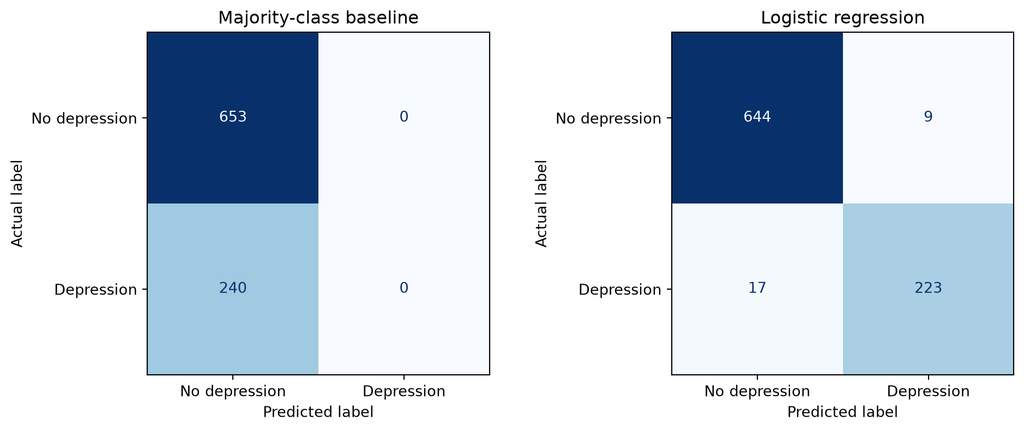

Figure 4: Held-out test confusion matrices. Each cell shows the number of students for the corresponding actual and predicted labels.

```python
fig, axes = plt.subplots(1, 2, figsize=(10, 4), layout="constrained")

for ax, (name, predictions) in zip(axes, test_predictions.items()):
    ConfusionMatrixDisplay.from_predictions(
        y_test,
        predictions,
        labels=[0, 1],
        display_labels=["No depression", "Depression"],
        cmap="Blues",
        colorbar=False,
        ax=ax,
    )
    ax.set_title(name)
    ax.set_xlabel("Predicted label")
    ax.set_ylabel("Actual label")

plt.show()
```

# 8 Result Discussion

Overall, our model achieved an accuracy of 97.1% (0.971), substantially outperforming the majority-class baseline of 73.1% (0.731). The model’s precision is 0.961, indicating that when it predicts a student has depression, it is correct the vast majority of the time, resulting in very few false alarms (false positives). However, our recall is slightly lower at 0.929. Comparing these two metrics shows that the model produces more false negatives than false positives, though the gap is relatively small.

Overall, the F1-score of 0.945 reflects a strong balance between precision and recall. However, for future fine-tuning, we should prioritize improving recall over precision to minimize false negatives—ensuring we do not miss students who actually have depression and need support.

Table 5: Five most negative and five most positive logistic regression coefficients.

```
categorical__Health_condition_Good                   -6.178
categorical__Health_condition_Normal                 -3.931
categorical__Relationship_status_In a Relationship   -2.164
categorical__Marital_status_Married                  -1.474
categorical__Family_background_Rich class            -1.398
categorical__friend_circle_No                         0.761
categorical__Health_condition_Abnormal                1.164
categorical__Marital_status_Unmarried                 1.500
categorical__Relationship_status_Single               2.662
categorical__Health_condition_Critical                8.924
Name: Coefficient, dtype: float64
```

Table 5 shows the five most negative and five most positive coefficients from the logistic regression model. Health condition had the largest coefficient in both directions, ranging from −6.18 to +8.92 across the categories shown. Holding the other predictors constant, this means the model assigned very different odds of a Yes depression label depending on the student’s health-condition category. This pattern is consistent with our exploratory analysis, where no students in the “Good” category had a Yes label, while all students in the “Critical” category did.

## 8.1 Limitations and implications

In the training data, every record in the “Critical” health-condition category was labeled “Yes” for depression, and every record in the “Good” category was labeled “No.” This close alignment may help explain why logistic regression achieved a test F1 score of 0.945. Our interpretation assumes that health condition was measured independently of the depression label and would be available at prediction time. If the health-condition rating incorporated information used to assign the depression label, the reported score could overstate performance in settings where that information is unavailable.

The held-out test set came from the same dataset as the training set, so we do not know how well the model would perform at other institutions. The model’s recall of 0.929 also means it missed about 7% of test records labeled “Yes.” A next step would be to evaluate the model on a deeper level and look at whether a different decision improves the recall while keeping false positives at a lower rate than the results originally showed.

# 9 References

- OpenAI. (2026). *ChatGPT* [Large language model]. https://chatgpt.com/
- Auerbach, R. P., et al. (2018). WHO World Mental Health Surveys International College Student Project: Prevalence and distribution of mental disorders. *Journal of Abnormal Psychology, 127*(7), 623–638. https://doi.org/10.1037/abn0000362
- mkhoirulmustaqim. (n.d.). *Student Depression Detection Dataset* [Data set]. Kaggle. [Dataset page](https://www.kaggle.com/datasets/mkhoirulmustaqim/student-depression-detection-dataset)
- Pedregosa, F., et al. (2011). Scikit-learn: Machine learning in Python. *Journal of Machine Learning Research, 12*, 2825–2830. [Article](https://jmlr.org/papers/v12/pedregosa11a.html)